# Programming Exercise

### Previous

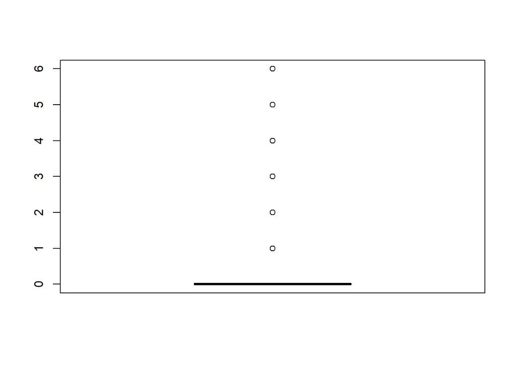

```r
boxplot(m_date$previous)
```

```r
summary(m_date$previous)
```

```
##    Min. 1st Qu.  Median    Mean 3rd Qu.    Max.
##  0.0000  0.0000  0.0000  0.1907  0.0000  6.0000
```

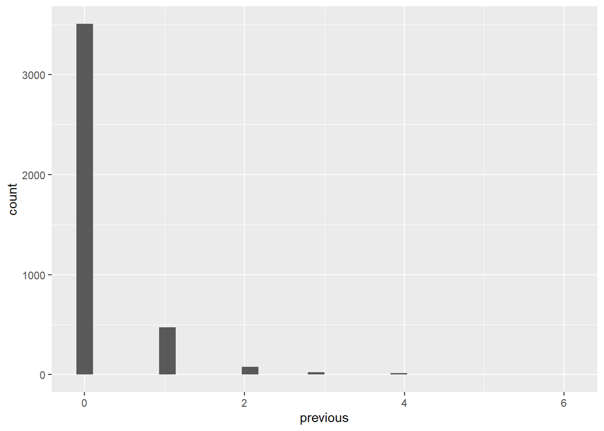

```r
ggplot(m_date,mapping = aes(previous)) + geom_histogram()
```

- Observation
  - The boxplot and historgram show that mostly there were no contacts performed before this campaign

### cons.conf.idx consumer confidence index

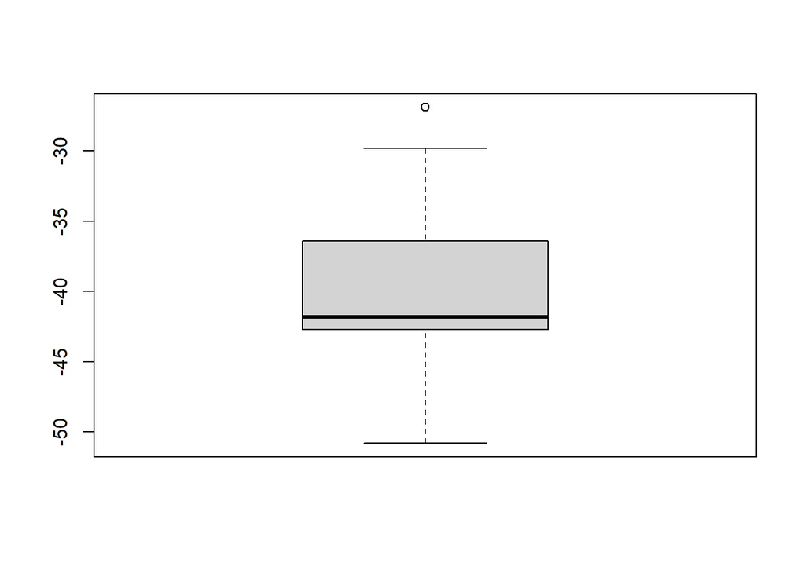

```r
boxplot(m_date$cons.conf.idx)
```

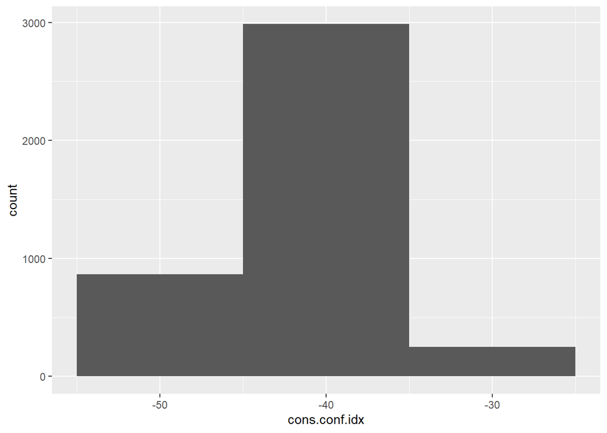

```r
ggplot(m_date,mapping = aes(cons.conf.idx)) + geom_histogram(binwidth = 10)
```

```r
summary(m_date$cons.conf.idx)
```

```
##    Min. 1st Qu.  Median    Mean 3rd Qu.    Max.
##   -50.8   -42.7   -41.8   -40.5   -36.4   -26.9
```

- Observation
  - the con.conf.idx contains negative values.
- One of the best methods for handling negative numbers in data analysis transformations is the log transformation (Rick, 2011).
  - Step 1
    - Shifting values to positive range

```r
m_date <- mutate(m_date,shifted_cons.conf.idx = m_date$cons.conf.idx - min(m_date$cons.conf.idx) + 1)
```

- Applying log transformation using log()

```r
m_date <- mutate(m_date,log_cons.conf.idx = log(m_date$shifted_cons.conf.idx))
```

```r
summary(m_date$log_cons.conf.idx)
```

```
##    Min. 1st Qu.  Median    Mean 3rd Qu.    Max.
##   0.000   2.208   2.303   2.326   2.734   3.215
```

### euribor3m

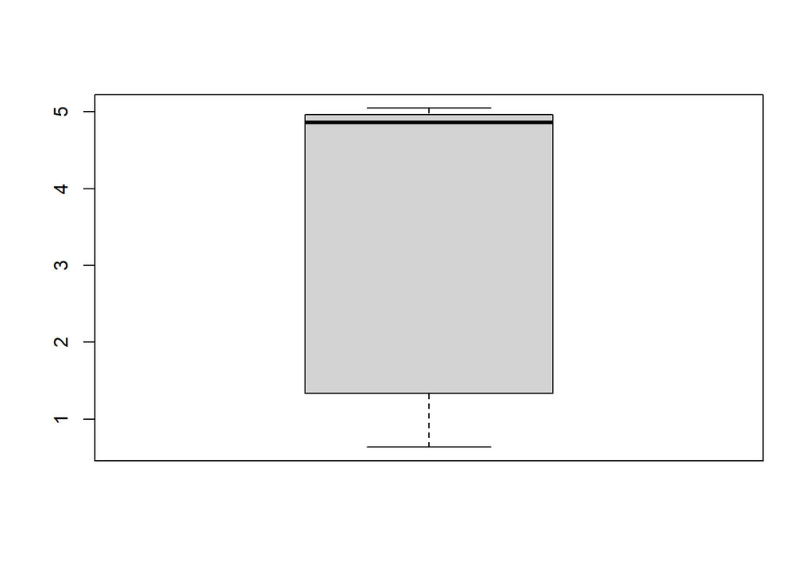

```r
boxplot(m_date$euribor3m)
```

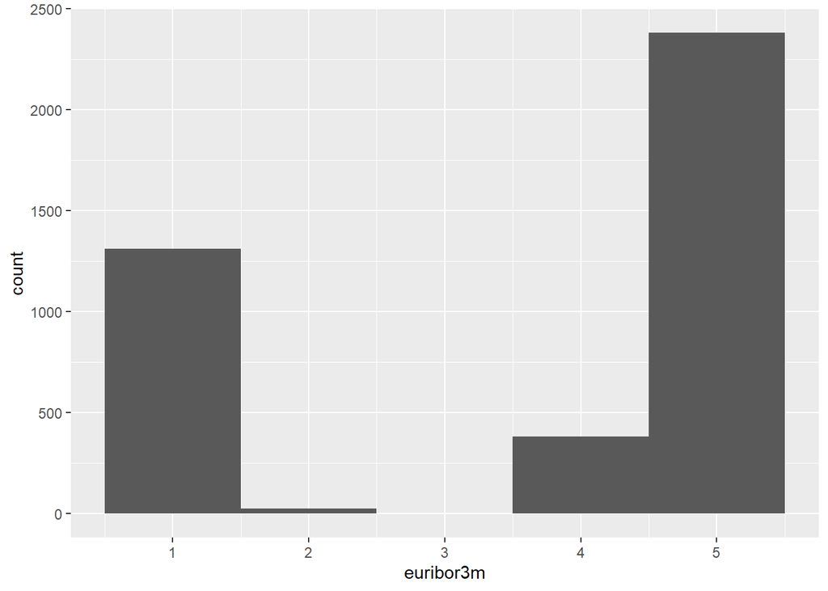

```r
ggplot(m_date,mapping = aes(euribor3m)) + geom_histogram(binwidth = 1)
```

```r
summary(m_date$euribor3m)
```

```
##    Min. 1st Qu.  Median    Mean 3rd Qu.    Max.
##   0.635   1.334   4.857   3.621   4.961   5.045
```

### nr.employed

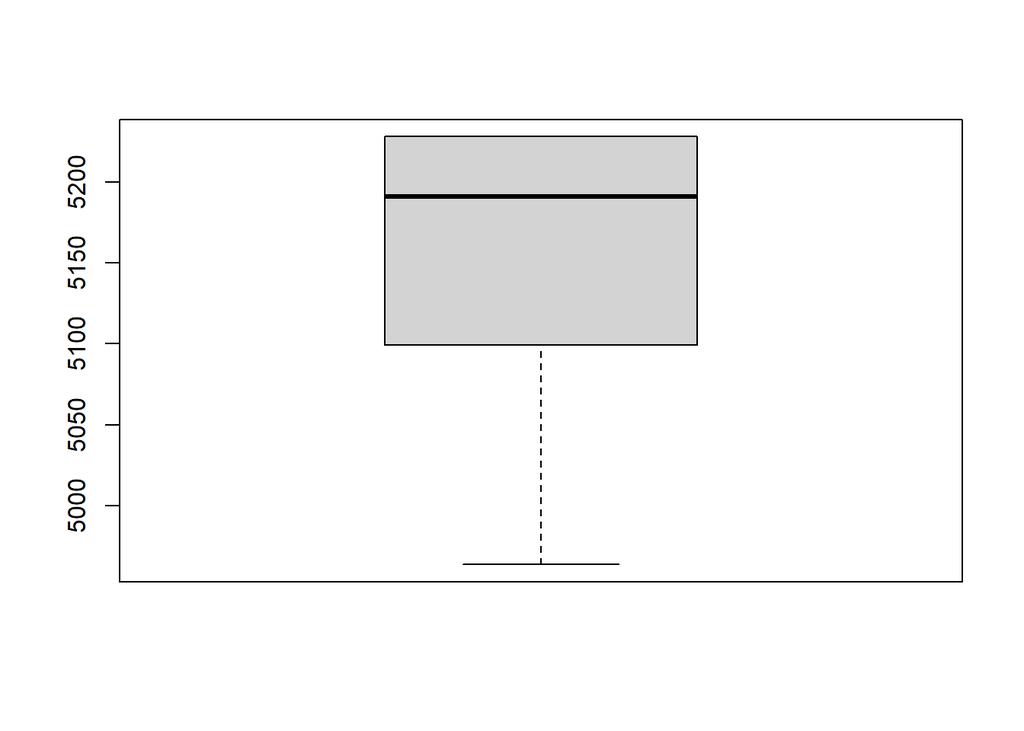

```r
boxplot(m_date$nr.employed)
```

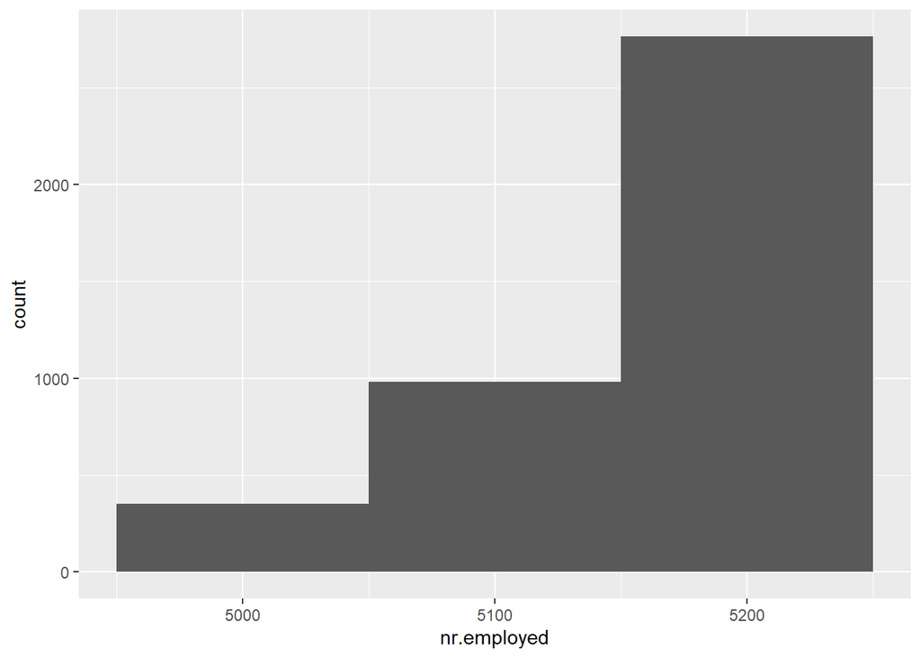

```r
ggplot(m_date,mapping = aes(nr.employed)) + geom_histogram(binwidth = 100)
```

## Descriptive Statistics

- numeric variables

```r
m_date %>% summarize_if(is.numeric, mean)
```

```
##        age duration campaign  previous emp.var.rate cons.price.idx
## 1 40.11707 256.7546 2.538537 0.1907317   0.08517073       93.58012
##   cons.conf.idx euribor3m nr.employed shifted_cons.conf.idx log_cons.conf.idx
## 1     -40.49846  3.621421    5166.473              11.30154          2.325588
```

- Examining the relationship between age and duration

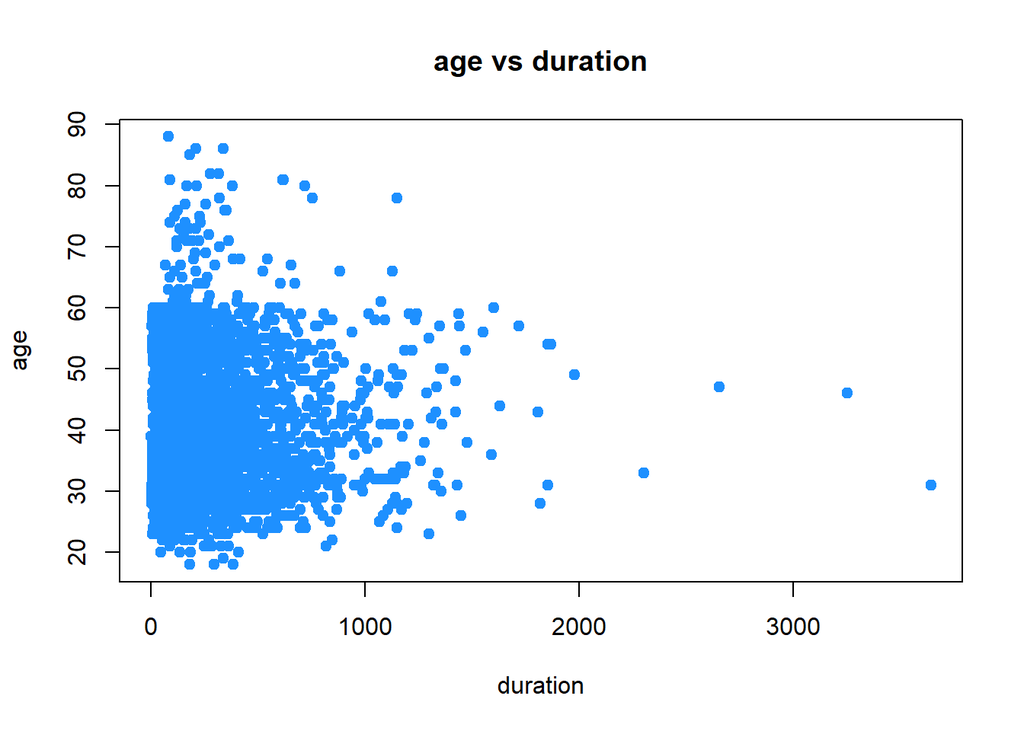

```r
plot(age ~ duration, data = m_date, col = "dodgerblue", pch = 20, cex = 1.5,
main = "age vs duration")
```